# Double Machine Learning

Inferência Causal - 2024/2

# Motivação

*Mari*

A inferência causal é uma área de estudo de interesse em várias áreas do conhecimento, como por exemplo a saúde, a economia.

No entanto, a complexidade dos problemas a serem resolvidos e o volume de dados a ser usado é cada vez maior.

Na inferência tradicional, podemos nos utilizar de técnicas de Machine Learning para contornar esse problema, uma vez que estes modelos são bons para lidar com problemas complexos e não exigem premissas fortes, como por exemplo linearidade.

Como podemos então utilizar Machine Learning para medir efeito causal?

É isto que propõe a técnica de **Double Machine Learning (DML)**!

## Intordução

Suponha que queremos medir o efeito do preço de nosso sorvete nas nossas vendas, controlando pelos confundidores: temperatura, custo e dia da semana.

A princípio suponha que usemos um modelo linear para remover o viés de nosso efeito causal:

$$Vendas_i=\alpha+\tau preço_i+\beta_1 temp_i + \beta_2 custo_i +\beta_3 dsem_i+\epsilon_i$$

Só estamos interessados no parâmetro $\tau$, mas como a estimação dos parâmetros é feita simultaneamente, precisamos nos preocupar na estimação dos demais parâmetros, pois afetarão a estimação do efeito causal.

Por exemplo, a relação de $temp$ provavelmente não é linear, pois em dias muito frios as pessoas não costumam sair, o que afetará nossas vendas, mas o mesmo pode ser dito para dias muito quentes, em que está tão quente que as pessoas preferem ficar em casa, no ar condicionado.

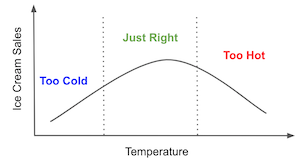

Dado isso, um modelo mais preciso seria o seguinte:

$$Vendas_i=\alpha+\tau preço_i+\beta_1 temp_i^2 + \beta_2 custo_i +\beta_3 dsem_i+\epsilon_i$$

Ou seja, note que quanto maior o número de variáveis mais complexo é definir essas interações. Devemos colocar quais polinômios, quais interações?

É um processo muito complexo que exige um estudo aprofundado de conhecimento de domínio.

# Teorema de Frisch-Waugh-Lovell

*Ciro*

Considere o seguinte modelo inicial,

$$Y_i = \tau T_i + \beta_1 X_{1i} + \beta_2 X_{2i} + \beta_3 X_{3i} + e_i$$

Vamos ajustar duas regressões lineares:

$$Y_i \sim X_{1i} + X_{2i} + X_{3i} \\
T_i \sim X_{1i} + X_{2i} + X_{3i}$$

A partir desses modelos obtemos dois resíduos, que chamaremos de $r_Y$ e $r_T$, respectivamente.

Agora, considere a seguinte regressão:

$$r_Y \sim r_T$$

O teorema de Frisch-Waugh-Lovell nos garante que esta regressão retorna o parâmetro $\tau$!

# Exemplo

```r
sample_n <- 10000

x1 <- rnorm(n = sample_n)
x2 <- rnorm(n = sample_n, 10)
t <- rnorm(sample_n, 5, .5)
y <- t * 2 + 0.2 * x1 + 0.5 * x2 + rnorm(sample_n)

fit_y <- lm(y ~ x1 + x2)
fit_t <- lm(t ~ x1 + x2)

fit <- lm(resid(fit_y) ~ resid(fit_t))
summary(fit)
```

```
Call:
lm(formula = resid(fit_y) ~ resid(fit_t))

Residuals:
    Min      1Q  Median      3Q     Max
-3.7315 -0.6739 -0.0077  0.6607  3.3275

Coefficients:
               Estimate Std. Error t value Pr(>|t|)
(Intercept)  -2.017e-16  9.965e-03    0.00        1
resid(fit_t)  1.988e+00  2.011e-02   98.84   <2e-16 ***
---
Signif. codes:  0 '***' 0.001 '**' 0.01 '*' 0.05 '.' 0.1 ' ' 1

Residual standard error: 0.9965 on 9998 degrees of freedom
Multiple R-squared:  0.4942,    Adjusted R-squared:  0.4942
F-statistic:  9770 on 1 and 9998 DF,  p-value: < 2.2e-16
```

## Limitações e pesquisas relacionadas

Que maravilha! Então podemos substituir as regressões intermdiárias por modelos não-paramétricos e agora não temos mais que nos preocupar com os demais parâmetros.

Mas peraí, podemos fazer isso?

Note que o teorema de Frisch-Waugh-Lovell (FWL) vale apenas para o cenário cujas relações são lineares.

Para nossa felicidade pessoas incríveis já extenderam esses resultados.

A princípio o resultado do FWL foi extendido para métodos “tradicionais” não-paramétricos, como Lasso (Bickel et al. - 1998).

Os resultados teóricos nesse momento se limitavam a estimadores que tomassem valor num conjunto de Donsker, o que eliminava muitos dos novos métodos.

Mais recentemente, conseguiram expandir os resultados para métodos mais novos como florestas, gradient boosting e outros (Chernozhukov et al. - 2014).

# Double/Orthgonal Machine Learning

*Sotelo*

Note que no teorema de FWL temos duas etapas intermediárias, que buscam estimar essas duas informações:

$$E[Y|X_2] \\
E[T|X_2]$$

O que o DML propõe é utilizarmos métodos não paramétricos para estimá-las.

Com o uso de modelos não paramétricos teríamos uma maneira de contornar as restrições de ter que nos atentar em todos parâmetros, deixando isso para esses modelos intermediários e focar nossa atenção em estimar o parâmetro causal.

Com isso, bastaríamos fazer a regressão linear dos resíduos desses modelos e teríamos o efeito causal $\tau$.

Vale ressaltar que quando analisado o efeito causal, não estamos falando de um efeito linear de fato, mas sim de um efeito linear local, sendo necessario cuidado ao analisá-lo para nao generalizá-lo para todo o intervalo real.

# Restrições clássicas de modelos paramétricos

*Renata* - Overfitting

## Possíveis soluções

- Cross validation

# Simulação de cenários reais